# Context and objectives

## Step 2 : Exploring the literature - Important conclusions

Exploring papers and online ressources around classification of bird sounds and decomposition of audio signals, we deduced that the key features to investigate in the next steps are the following:

- Spectral statistics extracted from the FFT-based spectrogram: the most important ones are related to the **mean frequency**, the **standard deviation** of the frequencies, and the frequency **mode** . We can also explore other statistics related to the frequencies we leverage from the signal (min, max, quartiles, etc...)
- Time summarisation statistics: Here we rely on time metrics, such as lenghts of the vocalizations or the silences.

In the next step, we will focus on investigating the spectral transformation of our initial signal.

## Step 3 : Visualizing audio signals and their 2D spectrograms

In this section, we will plot the spectogram of the signal above and see the useful frequency window :

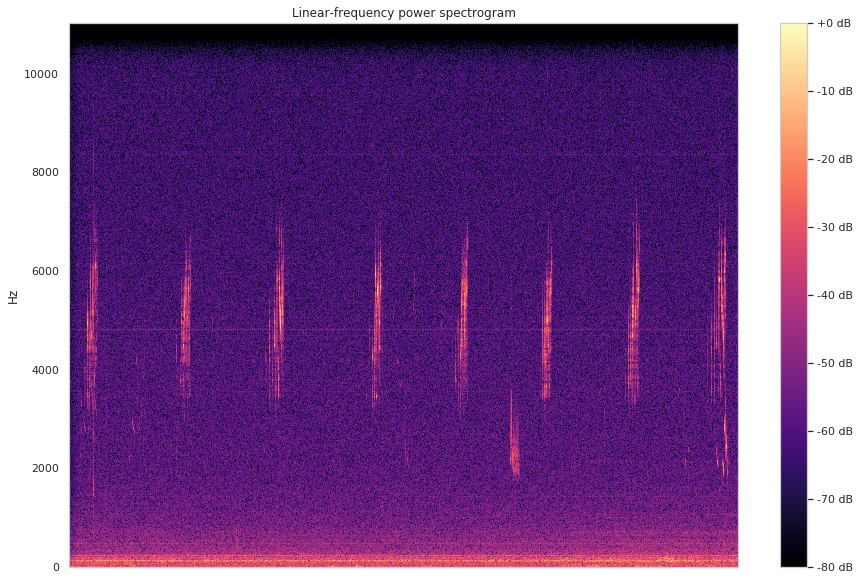

```python
D = librosa.amplitude_to_db(np.abs(librosa.stft(samples)), ref=np.max)

librosa.display.specshow(D, y_axis='linear')
plt.colorbar(format='%+2.0f dB')
plt.title('Linear-frequency power spectrogram')
plt.show()
```

Now let's look at the FFT transformation of our signal:

```python
def custom_fft(y, fs):
    T = 1.0 / fs
    N = y.shape[0]
    yf = np.fft.fft(y)
    xf = np.linspace(0.0, 1.0/(2.0*T), N//2)
    vals = 2.0/N * np.abs(yf[0:N//2])
    return xf, vals
```

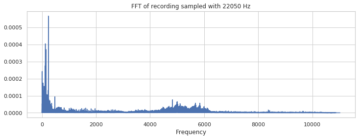

```python
xf, vals = custom_fft(samples, sample_rate)
plt.figure(figsize=(12, 4))
plt.title('FFT of recording sampled with ' + str(sample_rate) + ' Hz')
plt.plot(xf, vals)
plt.xlabel('Frequency')
plt.grid()
plt.show()
```

We cleary see here that the "useful" signal are between 4100 Hz and 6100 Hz. The rest is mostly noise we noticed earlier and that we need to remove.

We know that usually, the frequencies of the noise are centred to zero.

A very usufull information to know about birds : * Many bird songs have frequency ranges between 1000 Hz and 8000 Hz, which places them in the sweet spot of human hearing. On the high end, many warblers, sparrows, waxwings, kinglets, and a number of other birds produce sounds that reach 8000 Hz and beyond.

*NB*: To improve our approach, we can try to find an automatic way to find the peaks ( the useful signal ). We can use for example find_peaks_cwt, that is similar to findpeaks in matlab.

## Denoising the signal

Before moving forward with our analysis, let's implement a band-pass filter to try to reduce the background noise :

References : https://github.com/scipy/scipy/issues/8485

```python
def butter_bandpass(lowcut, highcut, fs, order=5):
    nyq = 0.5 * fs
    low = lowcut / nyq
    high = highcut / nyq
    b, a = butter(order, [low, high], btype='band')
    return b, a


def butter_bandpass_filter(data, lowcut, highcut, fs, order=5):
    b, a = butter_bandpass(lowcut, highcut, fs, order=order)
    y = lfilter(b, a, data)
    return y
```

```
No handles with labels found to put in legend.
```

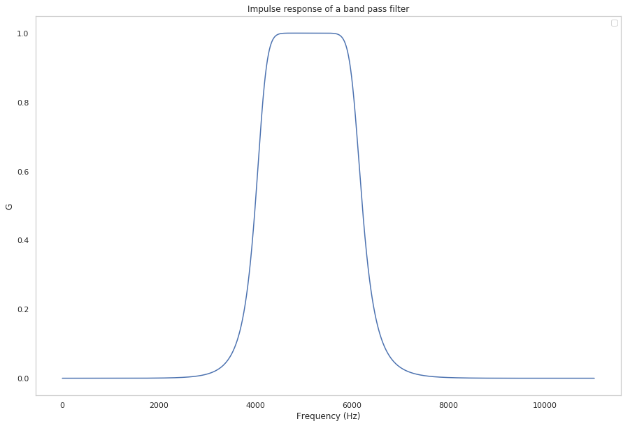

```python
#That we got above from the librosa function
fs = sample_rate

lowcut = 4100
highcut = 6100
#These values that Ive got manually from just vizulazing the spectogram.


# Plot the frequency response.
plt.figure(1)
plt.clf()
b, a = butter_bandpass(lowcut, highcut, fs)
w, h = freqz(b, a, worN=2000)
plt.plot((fs * 0.5 / np.pi) * w, abs(h))

plt.xlabel('Frequency (Hz)')
plt.ylabel('G')
plt.title('Impulse response of a band pass filter')
plt.legend(loc='best')
plt.show()
```

The selected frequencies are in the range defined earlier.

The new signal we've got :

```
No handles with labels found to put in legend.
```

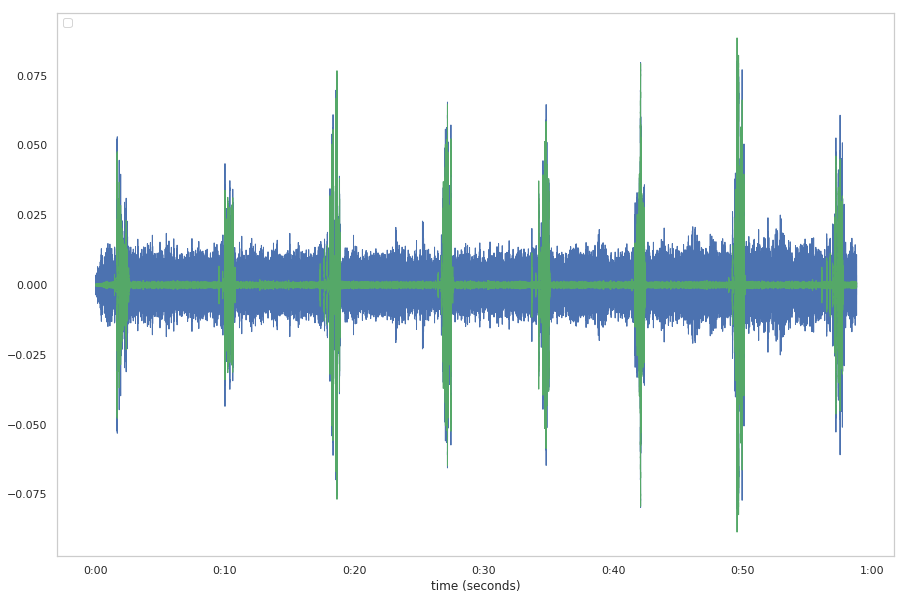

```python
### superimpose waveplots for filtred and real signal
filtered_signal = butter_bandpass_filter(samples, lowcut, highcut, fs, order=5)
librosa.display.waveplot(samples,fs)
librosa.display.waveplot(filtered_signal,fs,color='g')


plt.xlabel('time (seconds)')
plt.axis('tight')
plt.legend(loc='upper left')
plt.show()
```

The new spectogram we've got :

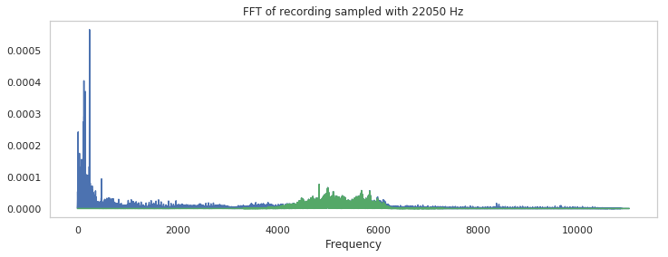

```python
xf, vals = custom_fft(filtered_signal, sample_rate)
xf_old, vals_old = custom_fft(samples, sample_rate)
plt.figure(figsize=(12, 4))
plt.title('FFT of recording sampled with ' + str(sample_rate) + ' Hz')
plt.plot(xf_old, vals_old)
plt.plot(xf, vals, color='g')
plt.xlabel('Frequency')
plt.show()
```

We see that we have removed the background noise keeping only the green signal which is more representative of the bird's real vocals. The spectrogram also displays the importants frequencies behind the birds vocalisation phases.

## First conclusions

We notice that in this case, the blue pipit audio has the following charasteristics:

- short intervals of equivalent lenghts with vocalisation of the bird with a similar magnitude repeated at a steady interval
- Long pauses in between represented by a flat line where the background noise used to be: the bird is silent for a while before resuming its activity and the noise was probably generated by the background.

This pattern is present on several blue pipit recordings and can be a useful way to distinguish blue pipits from other birds using a simple visual transformation of our signal.

We have also defined a fast method to denoise our signal based on using filters to reduce the noise. Now we can investigate further how we can extract useful feature to distinguish our blue pipits from other birds.

#### We will here try the same procedure, with an other type of birds :

We will try this with an other example of birds : The Blue-collared-Zipper.

```python
filename = 'Blue-collared-Zipper-251570.wav'

samples,sample_rate = librosa.load(str(train_audio_path) + filename)
```

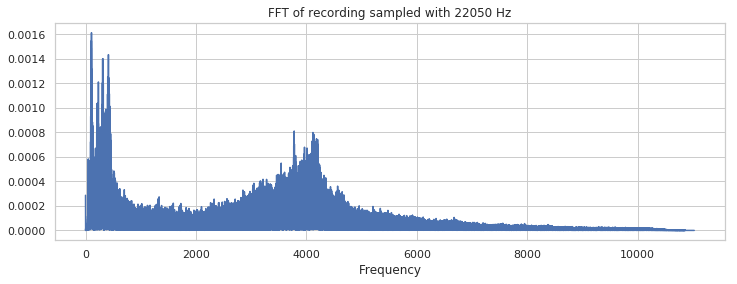

```python
xf, vals = custom_fft(samples, sample_rate)
plt.figure(figsize=(12, 4))
plt.title('FFT of recording sampled with ' + str(sample_rate) + ' Hz')
plt.plot(xf, vals)
plt.xlabel('Frequency')
plt.grid()
plt.show()
```

In this case, the useful signal is between 2800Hz and 5000 Hz.

```
No handles with labels found to put in legend.
```

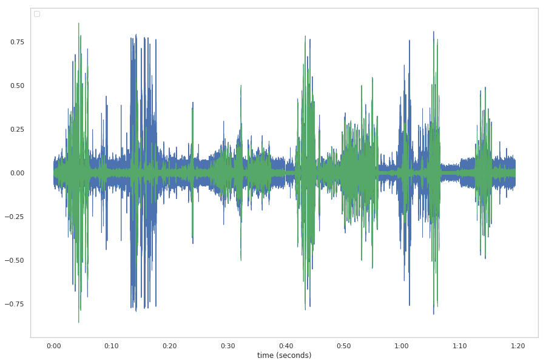

```python
#That we got above from the librosa function
fs = sample_rate

lowcut = 2800
highcut = 5000
#That we got manually from the vizualization.

filtered_signal = butter_bandpass_filter(samples, lowcut, highcut, fs, order=5)
librosa.display.waveplot(samples,fs)
librosa.display.waveplot(filtered_signal,fs,color='g')


plt.xlabel('time (seconds)')
plt.axis('tight')
plt.legend(loc='upper left')
plt.show()
```

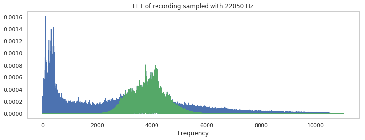

```python
xf, vals = custom_fft(filtered_signal, sample_rate)
xf_old, vals_old = custom_fft(samples, sample_rate)
plt.figure(figsize=(12, 4))
plt.title('FFT of recording sampled with ' + str(sample_rate) + ' Hz')
plt.plot(xf_old, vals_old)
plt.plot(xf, vals, color='g')
plt.xlabel('Frequency')
plt.show()
```

## Second conclusions

We clearly see that both birds have different sound frequency ranges that best represent their vocalisations. This way, we are able to distinguish the true voice frequency range of blue pipits versus other species.

In this part, we attempted using the useful frequency ranges as well as the signal's shape and magnitude as simple indicators of the birds species. Looking at the FFT representation and the signal plots have given us indicators on how to use time and frequency statistics to classify birds.

Now let's try to use a more complex approach.

# Features extraction : Finding visual features

We will try to define our signal's MFCC, which can be viewed as the signal's DNA representation. We hope to find correlated MFCCs for blue pipits that we can compare later to the Kasios audio files and come up with a conclusion on whether the blue pipits are back or not.

```python
def finding_name_files(dictionnaire,name):
    lower_cast_name=name.lower()
    res=[name for name, low_name in dictionnaire.items() if low_name == lower_cast_name]
    return res[0]
```

```python
def windows(data, window_size):
    start = 0
    while start < len(data):
        yield start, start + window_size
        start += (window_size // 2)
```

```python
def extract_features(parent_dir,file_ext=".wav",bands = 20, frames = 41):
    window_size = 512 * (frames - 1)
    mfccs = []

    pos={}
    nb=0
    nb_prev=0
    k=0

    for count in range(name_file.shape[0]):

        fn = os.path.join(parent_dir,finding_name_files(dictionnaire,name_file[count]+file_ext))

        # Load audio clip into librosa
        sound_clip,s = librosa.load(fn)

        # Normalize audio
        sound_clip_normalized = librosa.util.normalize(sound_clip)

        #-------------------------------------------------
        #-------------------------------------------------
        #DENOISING THE SIGNAL IS HERE
        #-------------------------------------------------
        #-------------------------------------------------

        # Split audio time series into non-silent sections
        split_array = librosa.effects.split(sound_clip_normalized, top_db=10, frame_length=32768, hop_length=256)
        split_chirps = []

        # Reform a single time series from the separate non-silent components
        for i,interval in enumerate(split_array):
            split_chirps.append(librosa.effects.remix(sound_clip_normalized, intervals=[interval]))

        # Loop through each individual audio segment (bird chirp) and apply MFCC to generate features
        k=0
        for i, audio_segment in enumerate(split_chirps):

            for (start,end) in windows(audio_segment,window_size):
                start = int(start)
                end = int(end)
                if(len(audio_segment[start:end]) == window_size):
                    signal = audio_segment[start:end]
                    mfcc = librosa.feature.mfcc(y=signal, sr=s, n_mfcc = bands).T.flatten()[:, np.newaxis].T
                    mfccs.append(mfcc)
                    k=k+1

        #Useful for the signal positions
        nb_prev=nb
        nb=nb+k
        pos[finding_name_files(dictionnaire,name_file[count]+file_ext)]=(nb_prev,nb)

    features = np.asarray(mfccs).reshape(len(mfccs),bands,frames)
    return np.array(features), pos
```

```python
#Different initializations:
parent_dir = 'ALL-BIRDS-WAV/'
sample_DF=pd.read_csv('AllBirdsv4.csv')

#---------------------------------------------------

#Getting the file names :
name_file=sample_DF['English_name']+'-'+sample_DF['File ID'].apply(str)
name_file=name_file.replace(' ', '-',regex=True)
name_file=name_file[:10]

#---------------------------------------------------

dictionnaire={}
wav_files = []

for root, dirs, files in os.walk("ALL-BIRDS-WAV/"):
    for filename in files:
        wav_files.append(filename)

for file in wav_files:
    dictionnaire[file]=str(file).lower()

#---------------------------------------------------

features, position = extract_features(parent_dir)
```

Some representations of the signal features :

```python
#Useful function for the features plots :
def ix(dic, n):
    return list(dic)[n]
```

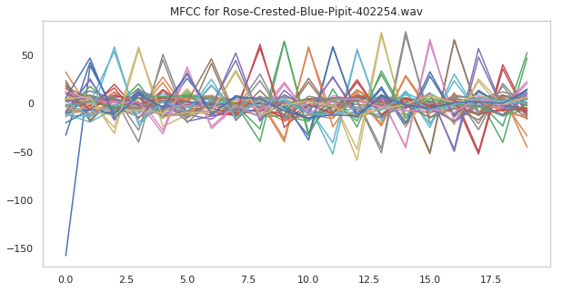

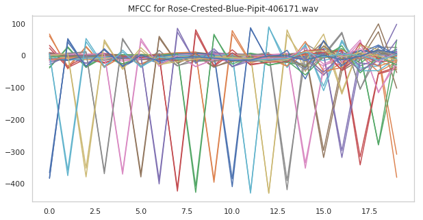

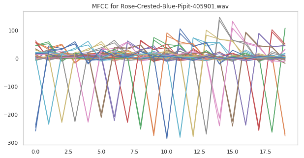

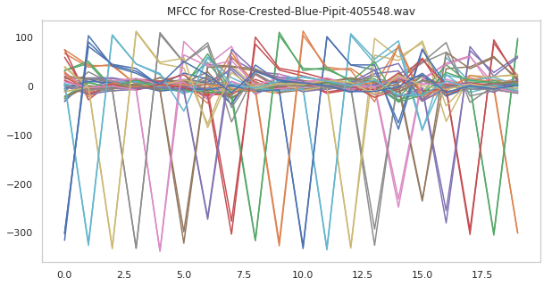

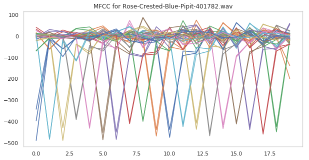

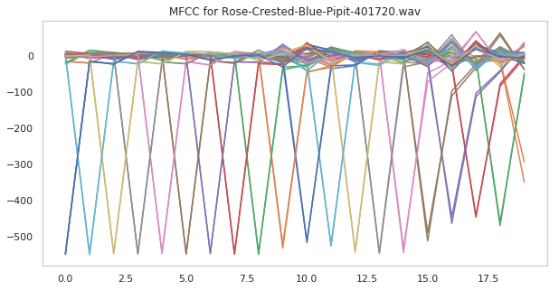

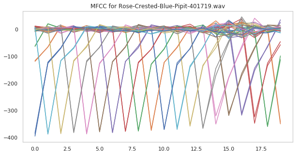

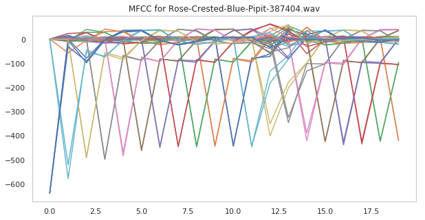

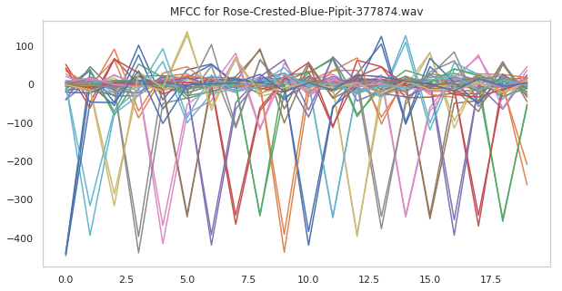

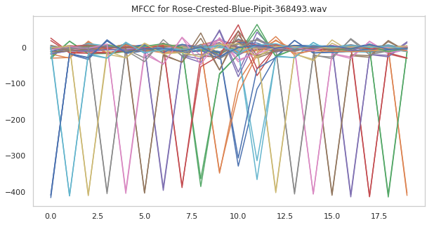

```python
for i in range(len(position)):
    plt.figure(figsize=(10,5))
    plt.plot(features[position[ix(position,i)][0]])
    plt.title('MFCC for '+ix(position,i))
    plt.show()
```

Let's look at the other bird category:

```python
name_file=np.array(['Blue-collared-Zipper-257777'])
```

```python
features, position = extract_features(parent_dir)
```

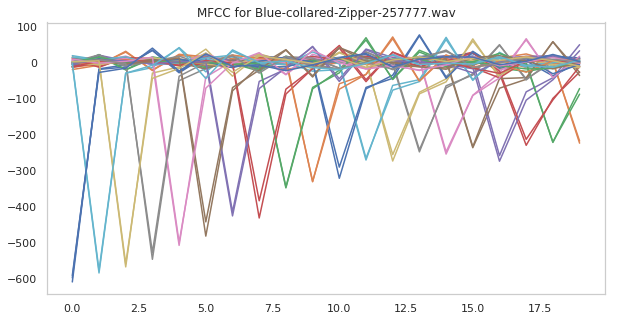

```python
for i in range(len(position)):
    plt.figure(figsize=(10,5))
    plt.plot(features[position[ix(position,i)][0]])
    plt.title('MFCC for '+ix(position,i))
    plt.show()
```

Conclusion : We see a different between the figure that corresponds for the Blue Collared Zipper, and between the 10 previous plots that correspond to the Blue Pipit. The shape of the MFCC seems to be an additionnal indicator on whether or not we are dealing with Blue Pipits.

References : https://github.com/chadstolper/vast-challenge-2018-mc1/blob/master/Bird_Classification.ipynb